# Capstone Project : Home Credit Default Risk

## Table of Contents:

1. Introduction
2. Import Libraries
3. Read and Import Data
4. Analyze Datasets
5. Clean Datasets  
   5.1 Deal with the Null values
6. Check for the outliers  
   6.1 Create Histograms for the non-categorical variables  
   6.2 Create Box Plots for the non-categorical variables  
   6.3 Create Count plots for the categorical variables  
   6.4 Create Count plot for the Target variable
7. Data Modeling  
   7.1 Impute Outliers  
   7.2 Delete Null value records  
   7.3 Categorical Variable Transformation  
   7.4 Logistic Regression  
   7.5 Logistic Regression Cross Validation  
   7.6 Random Forest Classifier  
   7.7 Random Forest Classifier Cross Validation  
   7.8 Gradient Boosting Classifier  
   7.9 Gradient Boosting Classifier Cross Validation
8. Results

## Introduction

Many people struggle to get loans due to insufficient or non-existent credit histories. And this population is often taken advantage of by untrustworthy lenders. Home Credit strives to broaden financial inclusion for this underserved population by providing a positive and safe borrowing experience. Our goal in this project is to help the Home Credit Loan Servicing team achieve their goal by building a model tuned for maximum accuracy that will predict the client’s capability of loan repayment. The model output will be a probability of loan repayment failure.

Target variable:  
1 - client with payment difficulties: he/she had late payment more than X days on at least one of the first Y installments of the loan in our sample.  
0 - all other cases.

## Import Libraries

```python
import numpy as np
import pandas as pd
import matplotlib.pyplot as plt
import seaborn as sns
```

## Read and Import Data

```python
app_train=pd.read_csv("application_train.csv")
prev_app=pd.read_csv("previous_application.csv")
bureau=pd.read_csv("bureau.csv")
bureau_bal=pd.read_csv("bureau_balance.csv")
pos_cash_bal=pd.read_csv("POS_CASH_balance.csv")
installments_pay=pd.read_csv("installments_payments.csv")
creditcard_bal=pd.read_csv("credit_card_balance.csv")
```

## Analyze Datasets

```python
print(f" The shape of the Train data = {app_train.shape}")
print(f" The shape of the previous application data = {prev_app.shape}")
print(f" The shape of the bureau data = {bureau.shape}")
print(f" The shape of the bureau balance data = {bureau_bal.shape}")
print(f" The shape of the POS Cash balance data = {pos_cash_bal.shape}")
print(f" The shape of the installments payments data = {installments_pay.shape}")
print(f" The shape of the credit card balance data = {creditcard_bal.shape}")
```

```
 The shape of the Train data = (307511, 122)
 The shape of the previous application data = (1670214, 37)
 The shape of the bureau data = (1716428, 17)
 The shape of the bureau balance data = (27299925, 3)
 The shape of the POS Cash balance data = (10001358, 8)
 The shape of the installments payments data = (13605401, 8)
 The shape of the credit card balance data = (3840312, 23)
```

```python
print(f" The number of unique SK_ID_CURR in Train data = {app_train.SK_ID_CURR.nunique()}")
print(f" The number of unique SK_ID_CURR in POS Cash balance data = {pos_cash_bal.SK_ID_CURR.nunique()}")
print(f" The number of unique SK_ID_PREV in POS Cash balance data = {prev_app.SK_ID_PREV.nunique()}")
print(f" The number of unique SK_ID_CURR in installments payments data = {installments_pay.SK_ID_CURR.nunique()}")
print(f" The number of unique SK_ID_PREV in installments payments data = {prev_app.SK_ID_PREV.nunique()}")
print(f" The number of unique SK_ID_CURR in credit card balance data = {creditcard_bal.SK_ID_CURR.nunique()}")
print(f" The number of unique SK_ID_PREV in credit card balance data = {prev_app.SK_ID_PREV.nunique()}")
print(f" The number of unique SK_ID_CURR in previous application data = {prev_app.SK_ID_CURR.nunique()}")
print(f" The number of unique SK_ID_PREV in previous application data = {prev_app.SK_ID_PREV.nunique()}")
print(f" The number of unique SK_ID_CURR in bureau data = {bureau.SK_ID_CURR.nunique()}")
print(f" The number of unique SK_ID_BUREAU in bureau data = {bureau.SK_ID_BUREAU.nunique()}")
print(f" The number of unique SK_ID_BUREAU in bureau balance data = {bureau_bal.SK_ID_BUREAU.nunique()}")
```

```
 The number of unique SK_ID_CURR in Train data = 307511
 The number of unique SK_ID_CURR in POS Cash balance data = 337252
 The number of unique SK_ID_PREV in POS Cash balance data = 1670214
 The number of unique SK_ID_CURR in installments payments data = 339587
 The number of unique SK_ID_PREV in installments payments data = 1670214
 The number of unique SK_ID_CURR in credit card balance data = 103558
 The number of unique SK_ID_PREV in credit card balance data = 1670214
 The number of unique SK_ID_CURR in previous application data = 338857
 The number of unique SK_ID_PREV in previous application data = 1670214
 The number of unique SK_ID_CURR in bureau data = 305811
 The number of unique SK_ID_BUREAU in bureau data = 1716428
 The number of unique SK_ID_BUREAU in bureau balance data = 817395
```

```python
# Pull top 5 rows for data tables view
app_train.head()
prev_app.head()
bureau.head()
bureau_bal.head()
pos_cash_bal.head()
installments_pay.head()
creditcard_bal.head()
```

|  | SK_ID_PREV | SK_ID_CURR | MONTHS_BALANCE | AMT_BALANCE | AMT_CREDIT_LIMIT_ACTUAL | AMT_DRAWINGS_ATM_CURRENT | AMT_DRAWINGS_CURRENT | AMT_DRAWINGS_OTHER_CURRENT | AMT_DRAWINGS_POS_CURRENT | AMT_INST_MIN_REGULARITY | ... | AMT_RECIVABLE | AMT_TOTAL_RECEIVABLE | CNT_DRAWINGS_ATM_CURRENT | CNT_DRAWINGS_CURRENT | CNT_DRAWINGS_OTHER_CURRENT | CNT_DRAWINGS_POS_CURRENT | CNT_INSTALMENT_MATURE_CUM | NAME_CONTRACT_STATUS | SK_DPD | SK_DPD_DEF |
| --- | --- | --- | --- | --- | --- | --- | --- | --- | --- | --- | --- | --- | --- | --- | --- | --- | --- | --- | --- | --- | --- |
| 0 | 2562384 | 378907 | -6 | 56.970 | 135000 | 0.0 | 877.5 | 0.0 | 877.5 | 1700.325 | ... | 0.000 | 0.000 | 0.0 | 1 | 0.0 | 1.0 | 35.0 | Active | 0 | 0 |
| 1 | 2582071 | 363914 | -1 | 63975.555 | 45000 | 2250.0 | 2250.0 | 0.0 | 0.0 | 2250.000 | ... | 64875.555 | 64875.555 | 1.0 | 1 | 0.0 | 0.0 | 69.0 | Active | 0 | 0 |
| 2 | 1740877 | 371185 | -7 | 31815.225 | 450000 | 0.0 | 0.0 | 0.0 | 0.0 | 2250.000 | ... | 31460.085 | 31460.085 | 0.0 | 0 | 0.0 | 0.0 | 30.0 | Active | 0 | 0 |
| 3 | 1389973 | 337855 | -4 | 236572.110 | 225000 | 2250.0 | 2250.0 | 0.0 | 0.0 | 11795.760 | ... | 233048.970 | 233048.970 | 1.0 | 1 | 0.0 | 0.0 | 10.0 | Active | 0 | 0 |
| 4 | 1891521 | 126868 | -1 | 453919.455 | 450000 | 0.0 | 11547.0 | 0.0 | 11547.0 | 22924.890 | ... | 453919.455 | 453919.455 | 0.0 | 1 | 0.0 | 1.0 | 101.0 | Active | 0 | 0 |

5 rows × 23 columns

```python
# Check how many rows are null for each columns.
app_train.isna().sum()
prev_app.isna().sum()
bureau.isna().sum()
bureau_bal.isna().sum() # No null values
pos_cash_bal.isna().sum()
installments_pay.isna().sum()
creditcard_bal.isna().sum()
```

```
SK_ID_PREV                         0
SK_ID_CURR                         0
MONTHS_BALANCE                     0
AMT_BALANCE                        0
AMT_CREDIT_LIMIT_ACTUAL            0
AMT_DRAWINGS_ATM_CURRENT      749816
AMT_DRAWINGS_CURRENT               0
AMT_DRAWINGS_OTHER_CURRENT    749816
AMT_DRAWINGS_POS_CURRENT      749816
AMT_INST_MIN_REGULARITY       305236
AMT_PAYMENT_CURRENT           767988
AMT_PAYMENT_TOTAL_CURRENT          0
AMT_RECEIVABLE_PRINCIPAL           0
AMT_RECIVABLE                      0
AMT_TOTAL_RECEIVABLE               0
CNT_DRAWINGS_ATM_CURRENT      749816
CNT_DRAWINGS_CURRENT               0
CNT_DRAWINGS_OTHER_CURRENT    749816
CNT_DRAWINGS_POS_CURRENT      749816
CNT_INSTALMENT_MATURE_CUM     305236
NAME_CONTRACT_STATUS               0
SK_DPD                             0
SK_DPD_DEF                         0
dtype: int64
```

We can see a lot of the columns have many null values. All of the data tables with the exception of Bureau balance have columns with null values.

```python
# Check for any columns with all null values.
app_train.isnull().all().sum()
prev_app.isnull().all().sum()
bureau.isnull().all().sum()
bureau_bal.isnull().all().sum()
pos_cash_bal.isnull().all().sum()
installments_pay.isnull().all().sum()
creditcard_bal.isnull().all().sum()
```

```
0
```

There are no columns with all null values in the datasets.

```python
# Check for any duplicated rows. There was none.
app_train.duplicated().sum()
prev_app.duplicated().sum()
bureau.duplicated().sum()
bureau_bal.duplicated().sum()
pos_cash_bal.duplicated().sum()
installments_pay.duplicated().sum()
creditcard_bal.duplicated().sum()
```

```
0
```

There are no duplicated rows in the datasets.

```python
# Function to calculate missing values by column# Funct
def missing_values_table(df):
        # Total missing values
        mis_val = df.isnull().sum()
        # Percentage of missing values
        mis_val_percent = 100 * df.isnull().sum() / len(df)
        # Make a table with the results
        mis_val_table = pd.concat([mis_val, mis_val_percent], axis=1,ignore_index= True)
        # Rename the columns
        mis_val_table = mis_val_table.rename(
        columns = {0 : 'Missing Values', 1 : '% of Total Values'})
        # Sort the table by percentage of missing descending
        mis_val_table = mis_val_table[
            mis_val_table.iloc[:,1] != 0].sort_values(
        '% of Total Values', ascending=False).round(1)
        # Print some summary information
        print ("The dataframe has " + str(df.shape[1]) + " columns.\n"
            "There are " + str(mis_val_table.shape[0]) +
              " columns that have missing values.")
        # Return the dataframe with missing information
        return mis_val_table
```

```python
mis_val_table = missing_values_table(app_train)
mis_val_table.head(20)
#mis_val_table.tail(20)
```

```
The dataframe has 122 columns.
There are 67 columns that have missing values.
```

|  | Missing Values | % of Total Values |
| --- | --- | --- |
| COMMONAREA_MEDI | 214865 | 69.9 |
| COMMONAREA_AVG | 214865 | 69.9 |
| COMMONAREA_MODE | 214865 | 69.9 |
| NONLIVINGAPARTMENTS_MEDI | 213514 | 69.4 |
| NONLIVINGAPARTMENTS_MODE | 213514 | 69.4 |
| NONLIVINGAPARTMENTS_AVG | 213514 | 69.4 |
| FONDKAPREMONT_MODE | 210295 | 68.4 |
| LIVINGAPARTMENTS_MODE | 210199 | 68.4 |
| LIVINGAPARTMENTS_MEDI | 210199 | 68.4 |
| LIVINGAPARTMENTS_AVG | 210199 | 68.4 |
| FLOORSMIN_MODE | 208642 | 67.8 |
| FLOORSMIN_MEDI | 208642 | 67.8 |
| FLOORSMIN_AVG | 208642 | 67.8 |
| YEARS_BUILD_MODE | 204488 | 66.5 |
| YEARS_BUILD_MEDI | 204488 | 66.5 |
| YEARS_BUILD_AVG | 204488 | 66.5 |
| OWN_CAR_AGE | 202929 | 66.0 |
| LANDAREA_AVG | 182590 | 59.4 |
| LANDAREA_MEDI | 182590 | 59.4 |
| LANDAREA_MODE | 182590 | 59.4 |

```python
mis_val_table = missing_values_table(prev_app)
mis_val_table.head(20)
```

```
The dataframe has 37 columns.
There are 16 columns that have missing values.
```

|  | Missing Values | % of Total Values |
| --- | --- | --- |
| RATE_INTEREST_PRIMARY | 1664263 | 99.6 |
| RATE_INTEREST_PRIVILEGED | 1664263 | 99.6 |
| AMT_DOWN_PAYMENT | 895844 | 53.6 |
| RATE_DOWN_PAYMENT | 895844 | 53.6 |
| NAME_TYPE_SUITE | 820405 | 49.1 |
| DAYS_FIRST_DRAWING | 673065 | 40.3 |
| DAYS_FIRST_DUE | 673065 | 40.3 |
| DAYS_LAST_DUE_1ST_VERSION | 673065 | 40.3 |
| DAYS_LAST_DUE | 673065 | 40.3 |
| DAYS_TERMINATION | 673065 | 40.3 |
| NFLAG_INSURED_ON_APPROVAL | 673065 | 40.3 |
| AMT_GOODS_PRICE | 385515 | 23.1 |
| AMT_ANNUITY | 372235 | 22.3 |
| CNT_PAYMENT | 372230 | 22.3 |
| PRODUCT_COMBINATION | 346 | 0.0 |
| AMT_CREDIT | 1 | 0.0 |

```python
mis_val_table = missing_values_table(bureau)
mis_val_table.head(20)
```

```
The dataframe has 17 columns.
There are 7 columns that have missing values.
```

|  | Missing Values | % of Total Values |
| --- | --- | --- |
| AMT_ANNUITY | 1226791 | 71.5 |
| AMT_CREDIT_MAX_OVERDUE | 1124488 | 65.5 |
| DAYS_ENDDATE_FACT | 633653 | 36.9 |
| AMT_CREDIT_SUM_LIMIT | 591780 | 34.5 |
| AMT_CREDIT_SUM_DEBT | 257669 | 15.0 |
| DAYS_CREDIT_ENDDATE | 105553 | 6.1 |
| AMT_CREDIT_SUM | 13 | 0.0 |

```python
mis_val_table = missing_values_table(bureau_bal)
mis_val_table.head(20)
```

```
The dataframe has 3 columns.
There are 0 columns that have missing values.
```

|  | Missing Values | % of Total Values |
| --- | --- | --- |

```python
mis_val_table = missing_values_table(pos_cash_bal)
mis_val_table.head(20)
```

```
The dataframe has 8 columns.
There are 2 columns that have missing values.
```

|  | Missing Values | % of Total Values |
| --- | --- | --- |
| CNT_INSTALMENT_FUTURE | 26087 | 0.3 |
| CNT_INSTALMENT | 26071 | 0.3 |

```python
mis_val_table = missing_values_table(installments_pay)
mis_val_table.head(20)
```

```
The dataframe has 8 columns.
There are 2 columns that have missing values.
```

|  | Missing Values | % of Total Values |
| --- | --- | --- |
| DAYS_ENTRY_PAYMENT | 2905 | 0.0 |
| AMT_PAYMENT | 2905 | 0.0 |

```python
mis_val_table = missing_values_table(creditcard_bal)
mis_val_table.head(20)
```

```
The dataframe has 23 columns.
There are 9 columns that have missing values.
```

|  | Missing Values | % of Total Values |
| --- | --- | --- |
| AMT_PAYMENT_CURRENT | 767988 | 20.0 |
| AMT_DRAWINGS_ATM_CURRENT | 749816 | 19.5 |
| AMT_DRAWINGS_OTHER_CURRENT | 749816 | 19.5 |
| AMT_DRAWINGS_POS_CURRENT | 749816 | 19.5 |
| CNT_DRAWINGS_ATM_CURRENT | 749816 | 19.5 |
| CNT_DRAWINGS_OTHER_CURRENT | 749816 | 19.5 |
| CNT_DRAWINGS_POS_CURRENT | 749816 | 19.5 |
| AMT_INST_MIN_REGULARITY | 305236 | 7.9 |
| CNT_INSTALMENT_MATURE_CUM | 305236 | 7.9 |

## Clean Datasets

### Deal with the null values

We will remove the columns with null values > 25%. We might investigate them later if time permits. The data tables with >25% of null values are train data, previous application data and bureau data.

```python
#app_test.drop(app_train.columns[app_train.isnull().mean()>0.25],axis=1, inplace=True)
app_train.drop(app_train.columns[app_train.isnull().mean()>0.25],axis=1, inplace=True)
app_train.shape
```

```
(307511, 72)
```

```python
prev_app.drop(prev_app.columns[prev_app.isnull().mean()>0.25],axis=1, inplace=True)
prev_app.shape
```

```
(1670214, 26)
```

```python
bureau.drop(bureau.columns[bureau.isnull().mean()>0.25],axis=1, inplace=True)
bureau.shape
```

```
(1716428, 13)
```

## Check for the outliers

```python
# Pull the overall statistics of the data tables
app_train.describe()
prev_app.describe()
bureau.describe()
bureau_bal.describe()
pos_cash_bal.describe()
installments_pay.describe()
creditcard_bal.describe()
```

|  | SK_ID_PREV | SK_ID_CURR | MONTHS_BALANCE | AMT_BALANCE | AMT_CREDIT_LIMIT_ACTUAL | AMT_DRAWINGS_ATM_CURRENT | AMT_DRAWINGS_CURRENT | AMT_DRAWINGS_OTHER_CURRENT | AMT_DRAWINGS_POS_CURRENT | AMT_INST_MIN_REGULARITY | ... | AMT_RECEIVABLE_PRINCIPAL | AMT_RECIVABLE | AMT_TOTAL_RECEIVABLE | CNT_DRAWINGS_ATM_CURRENT | CNT_DRAWINGS_CURRENT | CNT_DRAWINGS_OTHER_CURRENT | CNT_DRAWINGS_POS_CURRENT | CNT_INSTALMENT_MATURE_CUM | SK_DPD | SK_DPD_DEF |
| --- | --- | --- | --- | --- | --- | --- | --- | --- | --- | --- | --- | --- | --- | --- | --- | --- | --- | --- | --- | --- | --- |
| count | 3.840312e+06 | 3.840312e+06 | 3.840312e+06 | 3.840312e+06 | 3.840312e+06 | 3.090496e+06 | 3.840312e+06 | 3.090496e+06 | 3.090496e+06 | 3.535076e+06 | ... | 3.840312e+06 | 3.840312e+06 | 3.840312e+06 | 3.090496e+06 | 3.840312e+06 | 3.090496e+06 | 3.090496e+06 | 3.535076e+06 | 3.840312e+06 | 3.840312e+06 |
| mean | 1.904504e+06 | 2.783242e+05 | -3.452192e+01 | 5.830016e+04 | 1.538080e+05 | 5.961325e+03 | 7.433388e+03 | 2.881696e+02 | 2.968805e+03 | 3.540204e+03 | ... | 5.596588e+04 | 5.808881e+04 | 5.809829e+04 | 3.094490e-01 | 7.031439e-01 | 4.812496e-03 | 5.594791e-01 | 2.082508e+01 | 9.283667e+00 | 3.316220e-01 |
| std | 5.364695e+05 | 1.027045e+05 | 2.666775e+01 | 1.063070e+05 | 1.651457e+05 | 2.822569e+04 | 3.384608e+04 | 8.201989e+03 | 2.079689e+04 | 5.600154e+03 | ... | 1.025336e+05 | 1.059654e+05 | 1.059718e+05 | 1.100401e+00 | 3.190347e+00 | 8.263861e-02 | 3.240649e+00 | 2.005149e+01 | 9.751570e+01 | 2.147923e+01 |
| min | 1.000018e+06 | 1.000060e+05 | -9.600000e+01 | -4.202502e+05 | 0.000000e+00 | -6.827310e+03 | -6.211620e+03 | 0.000000e+00 | 0.000000e+00 | 0.000000e+00 | ... | -4.233058e+05 | -4.202502e+05 | -4.202502e+05 | 0.000000e+00 | 0.000000e+00 | 0.000000e+00 | 0.000000e+00 | 0.000000e+00 | 0.000000e+00 | 0.000000e+00 |
| 25% | 1.434385e+06 | 1.895170e+05 | -5.500000e+01 | 0.000000e+00 | 4.500000e+04 | 0.000000e+00 | 0.000000e+00 | 0.000000e+00 | 0.000000e+00 | 0.000000e+00 | ... | 0.000000e+00 | 0.000000e+00 | 0.000000e+00 | 0.000000e+00 | 0.000000e+00 | 0.000000e+00 | 0.000000e+00 | 4.000000e+00 | 0.000000e+00 | 0.000000e+00 |
| 50% | 1.897122e+06 | 2.783960e+05 | -2.800000e+01 | 0.000000e+00 | 1.125000e+05 | 0.000000e+00 | 0.000000e+00 | 0.000000e+00 | 0.000000e+00 | 0.000000e+00 | ... | 0.000000e+00 | 0.000000e+00 | 0.000000e+00 | 0.000000e+00 | 0.000000e+00 | 0.000000e+00 | 0.000000e+00 | 1.500000e+01 | 0.000000e+00 | 0.000000e+00 |
| 75% | 2.369328e+06 | 3.675800e+05 | -1.100000e+01 | 8.904669e+04 | 1.800000e+05 | 0.000000e+00 | 0.000000e+00 | 0.000000e+00 | 0.000000e+00 | 6.633911e+03 | ... | 8.535924e+04 | 8.889949e+04 | 8.891451e+04 | 0.000000e+00 | 0.000000e+00 | 0.000000e+00 | 0.000000e+00 | 3.200000e+01 | 0.000000e+00 | 0.000000e+00 |
| max | 2.843496e+06 | 4.562500e+05 | -1.000000e+00 | 1.505902e+06 | 1.350000e+06 | 2.115000e+06 | 2.287098e+06 | 1.529847e+06 | 2.239274e+06 | 2.028820e+05 | ... | 1.472317e+06 | 1.493338e+06 | 1.493338e+06 | 5.100000e+01 | 1.650000e+02 | 1.200000e+01 | 1.650000e+02 | 1.200000e+02 | 3.260000e+03 | 3.260000e+03 |

8 rows × 22 columns

### Create Histograms for the non-categorical variables

[output not shown]

[output cut: 42 more lines]

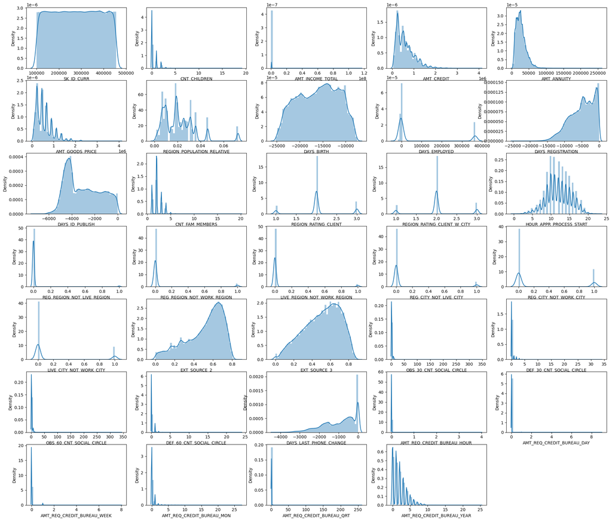

```python
# extract continuous columns
all_numerical_cols = list(app_train.select_dtypes(exclude='object').columns)

# continuous  columns are all columns excluding target and flags columns
cont_cols = [col for col in all_numerical_cols if col != "TARGET" and col[:5]!='FLAG_']

# draw histograms for each continuous column
plt.figure(figsize=(25, 50))
for i, col in enumerate(cont_cols):
    plt.subplot(16, 5, i+1)
    sns.distplot(app_train[col])
```

### Create Box-Plots for the non-categorical variables

[output not shown]

[output cut: 42 more lines]

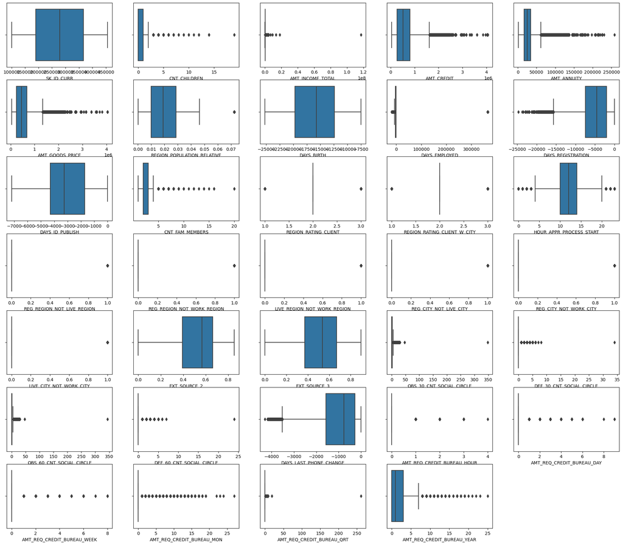

```python
# draw box plots for each continuous column
#import seaborn as sns
plt.figure(figsize=(25, 50))
for i, col in enumerate(cont_cols):
    plt.subplot(16, 5, i+1)
    sns.boxplot(app_train[col])
```

```python
app_train[cont_cols[1:13]].describe()
```

|  | CNT_CHILDREN | AMT_INCOME_TOTAL | AMT_CREDIT | AMT_ANNUITY | AMT_GOODS_PRICE | REGION_POPULATION_RELATIVE | DAYS_BIRTH | DAYS_EMPLOYED | DAYS_REGISTRATION | DAYS_ID_PUBLISH | CNT_FAM_MEMBERS | REGION_RATING_CLIENT |
| --- | --- | --- | --- | --- | --- | --- | --- | --- | --- | --- | --- | --- |
| count | 307511.000000 | 3.075110e+05 | 3.075110e+05 | 307499.000000 | 3.072330e+05 | 307511.000000 | 307511.000000 | 307511.000000 | 307511.000000 | 307511.000000 | 307509.000000 | 307511.000000 |
| mean | 0.417052 | 1.687979e+05 | 5.990260e+05 | 27108.573909 | 5.383962e+05 | 0.020868 | -16036.995067 | 63815.045904 | -4986.120328 | -2994.202373 | 2.152665 | 2.052463 |
| std | 0.722121 | 2.371231e+05 | 4.024908e+05 | 14493.737315 | 3.694465e+05 | 0.013831 | 4363.988632 | 141275.766519 | 3522.886321 | 1509.450419 | 0.910682 | 0.509034 |
| min | 0.000000 | 2.565000e+04 | 4.500000e+04 | 1615.500000 | 4.050000e+04 | 0.000290 | -25229.000000 | -17912.000000 | -24672.000000 | -7197.000000 | 1.000000 | 1.000000 |
| 25% | 0.000000 | 1.125000e+05 | 2.700000e+05 | 16524.000000 | 2.385000e+05 | 0.010006 | -19682.000000 | -2760.000000 | -7479.500000 | -4299.000000 | 2.000000 | 2.000000 |
| 50% | 0.000000 | 1.471500e+05 | 5.135310e+05 | 24903.000000 | 4.500000e+05 | 0.018850 | -15750.000000 | -1213.000000 | -4504.000000 | -3254.000000 | 2.000000 | 2.000000 |
| 75% | 1.000000 | 2.025000e+05 | 8.086500e+05 | 34596.000000 | 6.795000e+05 | 0.028663 | -12413.000000 | -289.000000 | -2010.000000 | -1720.000000 | 3.000000 | 2.000000 |
| max | 19.000000 | 1.170000e+08 | 4.050000e+06 | 258025.500000 | 4.050000e+06 | 0.072508 | -7489.000000 | 365243.000000 | 0.000000 | 0.000000 | 20.000000 | 3.000000 |

```python
app_train[cont_cols[13:26]].describe()
```

|  | REGION_RATING_CLIENT_W_CITY | HOUR_APPR_PROCESS_START | REG_REGION_NOT_LIVE_REGION | REG_REGION_NOT_WORK_REGION | LIVE_REGION_NOT_WORK_REGION | REG_CITY_NOT_LIVE_CITY | REG_CITY_NOT_WORK_CITY | LIVE_CITY_NOT_WORK_CITY | EXT_SOURCE_2 | EXT_SOURCE_3 | OBS_30_CNT_SOCIAL_CIRCLE | DEF_30_CNT_SOCIAL_CIRCLE | OBS_60_CNT_SOCIAL_CIRCLE |
| --- | --- | --- | --- | --- | --- | --- | --- | --- | --- | --- | --- | --- | --- |
| count | 307511.000000 | 307511.000000 | 307511.000000 | 307511.000000 | 307511.000000 | 307511.000000 | 307511.000000 | 307511.000000 | 3.068510e+05 | 246546.000000 | 306490.000000 | 306490.000000 | 306490.000000 |
| mean | 2.031521 | 12.063419 | 0.015144 | 0.050769 | 0.040659 | 0.078173 | 0.230454 | 0.179555 | 5.143927e-01 | 0.510853 | 1.422245 | 0.143421 | 1.405292 |
| std | 0.502737 | 3.265832 | 0.122126 | 0.219526 | 0.197499 | 0.268444 | 0.421124 | 0.383817 | 1.910602e-01 | 0.194844 | 2.400989 | 0.446698 | 2.379803 |
| min | 1.000000 | 0.000000 | 0.000000 | 0.000000 | 0.000000 | 0.000000 | 0.000000 | 0.000000 | 8.173617e-08 | 0.000527 | 0.000000 | 0.000000 | 0.000000 |
| 25% | 2.000000 | 10.000000 | 0.000000 | 0.000000 | 0.000000 | 0.000000 | 0.000000 | 0.000000 | 3.924574e-01 | 0.370650 | 0.000000 | 0.000000 | 0.000000 |
| 50% | 2.000000 | 12.000000 | 0.000000 | 0.000000 | 0.000000 | 0.000000 | 0.000000 | 0.000000 | 5.659614e-01 | 0.535276 | 0.000000 | 0.000000 | 0.000000 |
| 75% | 2.000000 | 14.000000 | 0.000000 | 0.000000 | 0.000000 | 0.000000 | 0.000000 | 0.000000 | 6.636171e-01 | 0.669057 | 2.000000 | 0.000000 | 2.000000 |
| max | 3.000000 | 23.000000 | 1.000000 | 1.000000 | 1.000000 | 1.000000 | 1.000000 | 1.000000 | 8.549997e-01 | 0.896010 | 348.000000 | 34.000000 | 344.000000 |

```python
app_train[cont_cols[26:39]].describe()
```

|  | DEF_60_CNT_SOCIAL_CIRCLE | DAYS_LAST_PHONE_CHANGE | AMT_REQ_CREDIT_BUREAU_HOUR | AMT_REQ_CREDIT_BUREAU_DAY | AMT_REQ_CREDIT_BUREAU_WEEK | AMT_REQ_CREDIT_BUREAU_MON | AMT_REQ_CREDIT_BUREAU_QRT | AMT_REQ_CREDIT_BUREAU_YEAR |
| --- | --- | --- | --- | --- | --- | --- | --- | --- |
| count | 306490.000000 | 307510.000000 | 265992.000000 | 265992.000000 | 265992.000000 | 265992.000000 | 265992.000000 | 265992.000000 |
| mean | 0.100049 | -962.858788 | 0.006402 | 0.007000 | 0.034362 | 0.267395 | 0.265474 | 1.899974 |
| std | 0.362291 | 826.808487 | 0.083849 | 0.110757 | 0.204685 | 0.916002 | 0.794056 | 1.869295 |
| min | 0.000000 | -4292.000000 | 0.000000 | 0.000000 | 0.000000 | 0.000000 | 0.000000 | 0.000000 |
| 25% | 0.000000 | -1570.000000 | 0.000000 | 0.000000 | 0.000000 | 0.000000 | 0.000000 | 0.000000 |
| 50% | 0.000000 | -757.000000 | 0.000000 | 0.000000 | 0.000000 | 0.000000 | 0.000000 | 1.000000 |
| 75% | 0.000000 | -274.000000 | 0.000000 | 0.000000 | 0.000000 | 0.000000 | 0.000000 | 3.000000 |
| max | 24.000000 | 0.000000 | 4.000000 | 9.000000 | 8.000000 | 27.000000 | 261.000000 | 25.000000 |

```python
#sns.distplot(app_train['AMT_INCOME_TOTAL'])
#plt.title('Density plot of Total Income')

#sns.distplot(app_train['DAYS_BIRTH'])
#plt.title('Density plot of DAYS_BIRTH')

#sns.distplot(app_train['DAYS_EMPLOYED'])
#plt.title('Density plot of DAYS_EMPLOYED')

#sns.distplot(app_train['CNT_CHILDREN'])
#plt.title('Density plot of Children Count')
```

### Create Count plots for the categorical variables

```python
cat_col = app_train.select_dtypes('object')
cat_col.describe()
```

|  | NAME_CONTRACT_TYPE | CODE_GENDER | FLAG_OWN_CAR | FLAG_OWN_REALTY | NAME_TYPE_SUITE | NAME_INCOME_TYPE | NAME_EDUCATION_TYPE | NAME_FAMILY_STATUS | NAME_HOUSING_TYPE | WEEKDAY_APPR_PROCESS_START | ORGANIZATION_TYPE |
| --- | --- | --- | --- | --- | --- | --- | --- | --- | --- | --- | --- |
| count | 307511 | 307511 | 307511 | 307511 | 306219 | 307511 | 307511 | 307511 | 307511 | 307511 | 307511 |
| unique | 2 | 3 | 2 | 2 | 7 | 8 | 5 | 6 | 6 | 7 | 58 |
| top | Cash loans | F | N | Y | Unaccompanied | Working | Secondary / secondary special | Married | House / apartment | TUESDAY | Business Entity Type 3 |
| freq | 278232 | 202448 | 202924 | 213312 | 248526 | 158774 | 218391 | 196432 | 272868 | 53901 | 67992 |

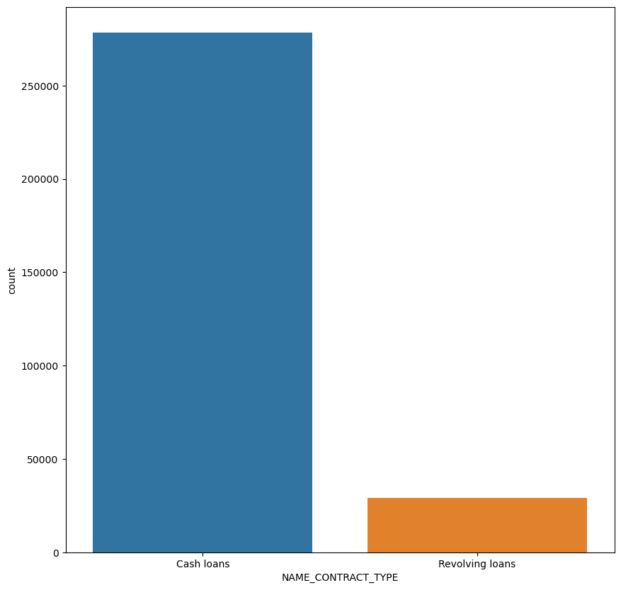

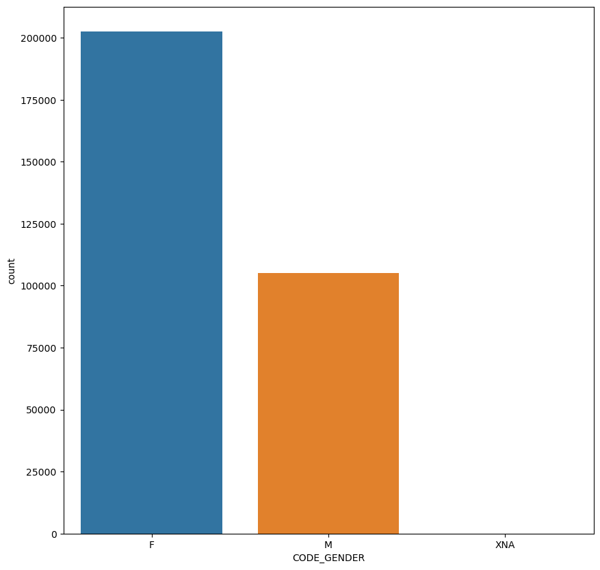

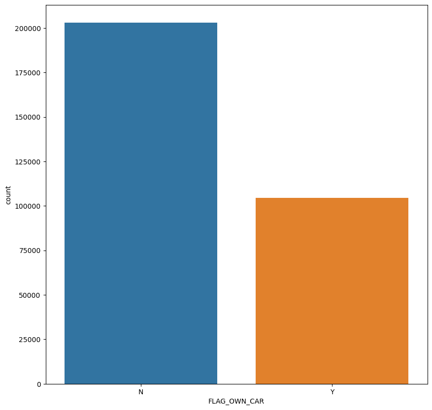

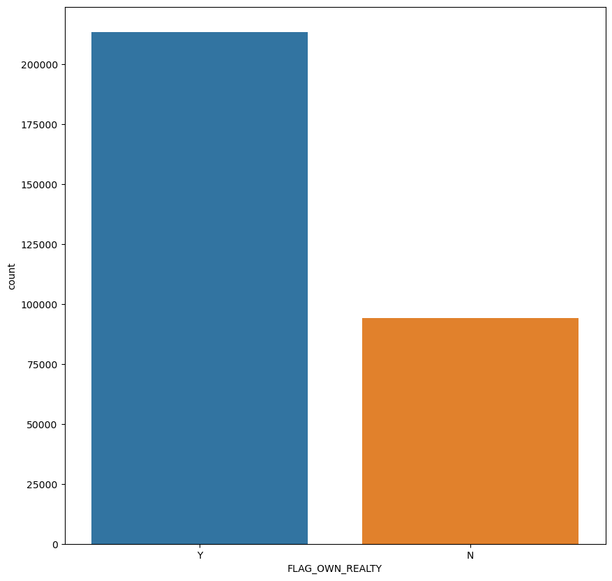

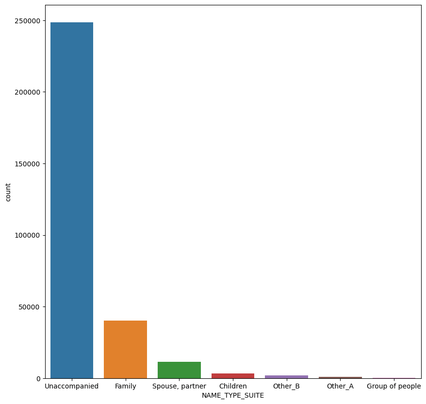

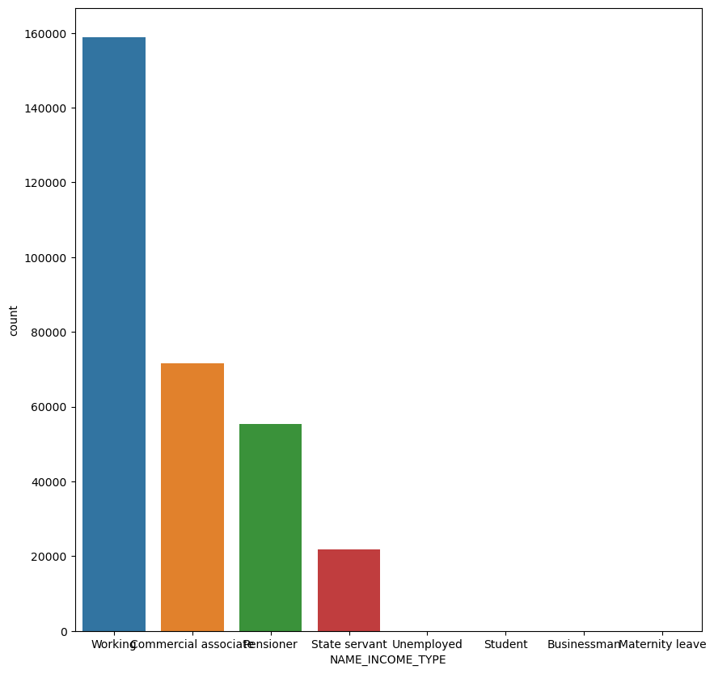

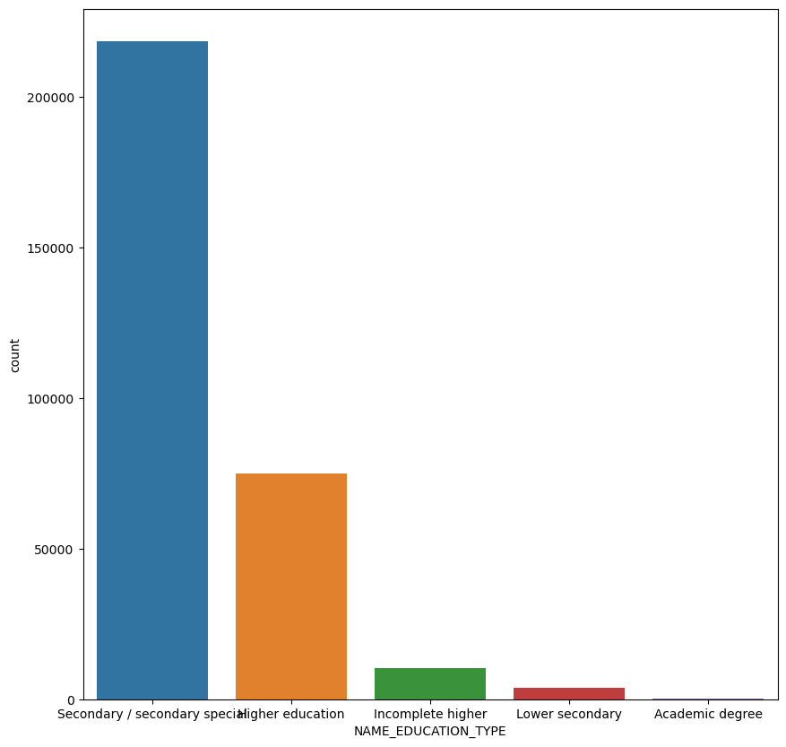

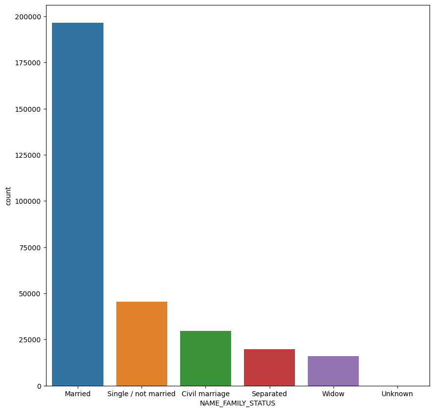

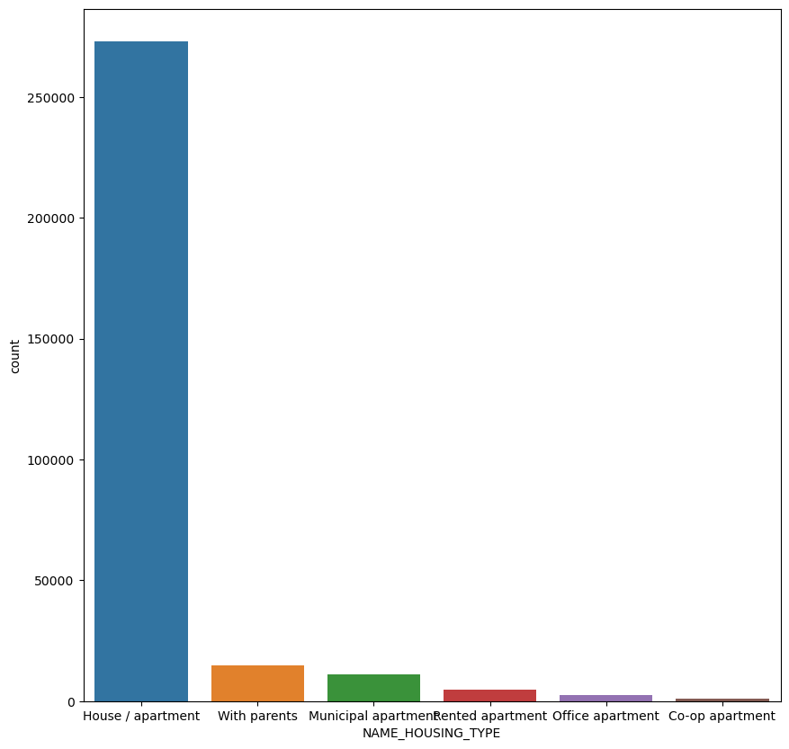

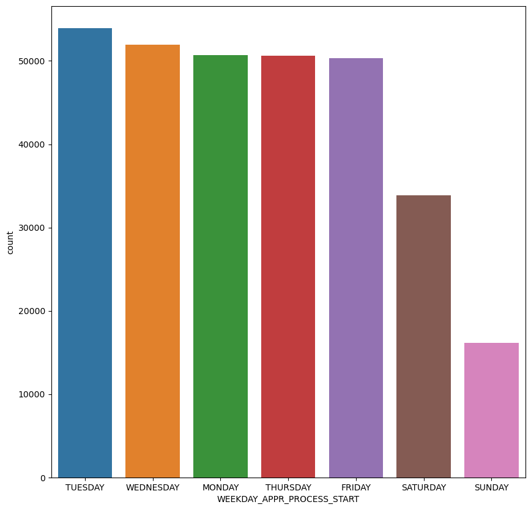

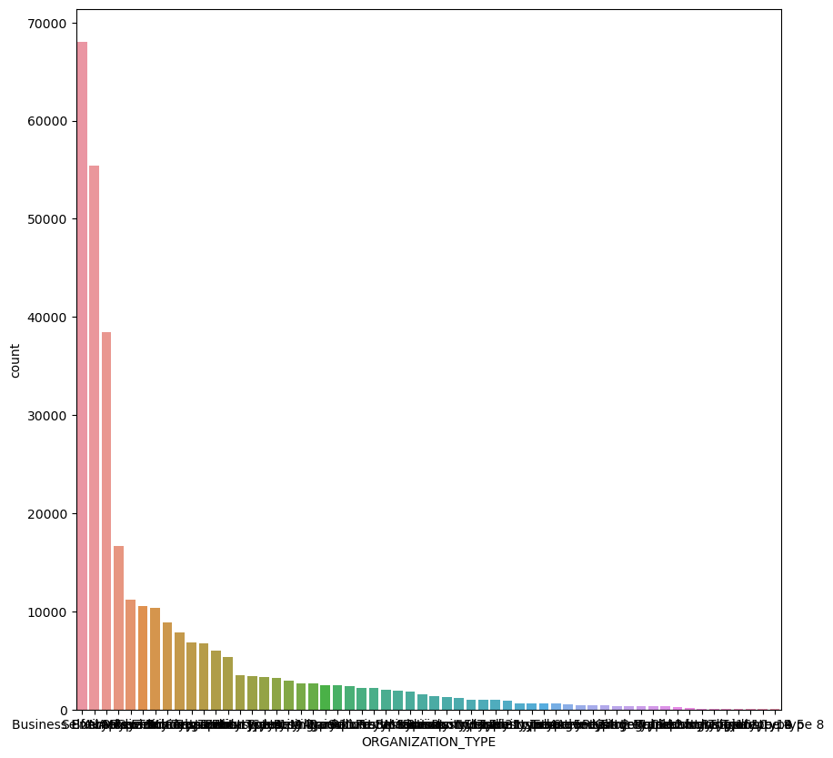

```python
for i in cat_col:
    plt.figure(figsize=(10,10))
    sns.countplot(cat_col[i], orient = 'h', order = cat_col[i].value_counts().index)
```

### Create count plot for the Target variable

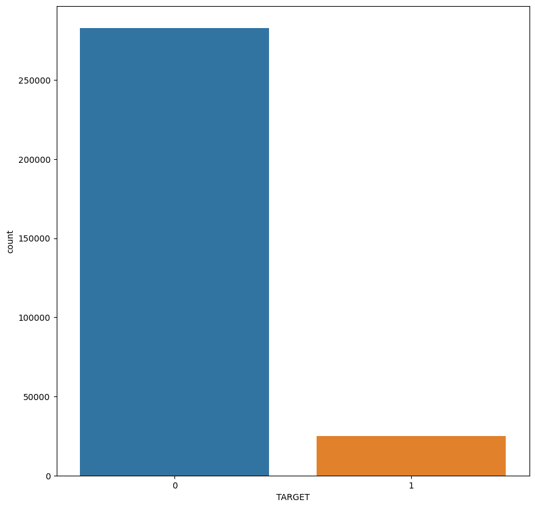

```python
plt.figure(figsize=(10,10))
sns.countplot(app_train['TARGET'], orient = 'h', order = app_train['TARGET'].value_counts().index)
#plt.xticks(rotation = 70)
```

```python
app_train['TARGET'].value_counts(normalize=True).reset_index()
```

|  | index | TARGET |
| --- | --- | --- |
| 0 | 0 | 0.919271 |
| 1 | 1 | 0.080729 |

## EDA Results

Based on the histograms, count plots and the statistical summary we can see theh distribution of most of the data attributes are skewed and consist outliers eg. CNT_CHILDREN, CNT_FAM_MEMBERS, DAYS_REGISTRATION, AMT_CREDIT etc. Also, 92% of the data in the train set is for the non-defaults and only 8% is for the defaults. We have tackled this partly by removing the columns with more than 25% null values. Based on the plots, seems we need to do more data cleaning to take care of the skewness and outliers.

## Data Modeling

The interquartile range (IQR) is a measurement of the spread of values in the middle 50%. If an observation is 1.5 times the interquartile range more than the third quartile (Q3) or 1.5 times the interquartile range less than the first quartile (Q1), it is considered and outlier.

### Delete null value records

Due to the sufficient size of the data, we will remove the nulls for now.

```python
#x = x.select_dtypes(exclude='object').columns
#x=app_train[['CNT_CHILDREN','AMT_INCOME_TOTAL', 'AMT_CREDIT']].to_numpy()
#X = X.to_numpy()
#X = app_train.drop(['TARGET'], axis='columns')
#get all categorical columns
#cat_columns = X.select_dtypes(['object']).columns

#convert all categorical columns to numeric
#X[cat_columns] = X[cat_columns].apply(lambda x: pd.factorize(x)[0])
#fill missing values with median
#X = X.fillna(X.median())
#y = app_train[['TARGET']].to_numpy()
```

```python
app_train_df=app_train.dropna(how='any',axis=0)
```

```python
app_train_df.shape
```

```
(244280, 72)
```

### Impute Outliers

Due to skewness in the data we will replace the outliers determined by IQR approach with the median values.

```python
#Remove Outliers using IQR
def remove_outliers(df, columns):
    for col in columns:
        Q1 = df[col].quantile(0.25)
        Q3 = df[col].quantile(0.75)
        IQR = Q3 - Q1
        lower_bound = Q1 - 1.5*IQR
        upper_bound = Q3 + 1.5*IQR
        df = df[(df[col] >= lower_bound) & (df[col] <= upper_bound)]
    return df
```

```python
def remove_outliers_iqr_values(df, columns):
    """
    Remove outlier values from a specified column in a pandas dataframe
    using the interquartile range (IQR) method without removing rows.

    Parameters:
    df (pandas.DataFrame): The input dataframe
    col (str): The name of the column to remove outlier values from

    Returns:
    pandas.DataFrame: The modified dataframe with outlier values replaced by NaN
    """
    for col in columns:
        Q1 = df[col].quantile(0.25)
        Q3 = df[col].quantile(0.75)
        IQR = Q3 - Q1
        lower_bound = Q1 - 1.5*IQR
        upper_bound = Q3 + 1.5*IQR
        df.loc[(df[col] < lower_bound) | (df[col] > upper_bound), col] = np.nan
    return df
```

```python
# specify columns to remove outliers from
all_numerical_cols = list(app_train_df.select_dtypes(exclude='object').columns)
# continuous  columns are all columns excluding target and flags columns
cont_cols = [col for col in all_numerical_cols if col != "TARGET" and col[:5]!='FLAG_']
# remove outliers using IQR for numeric columns
app_train_df = remove_outliers_iqr_values(app_train_df, cont_cols)
```

```python
app_train_df.shape
```

```
(244280, 72)
```

```python
app_train_df['TARGET'].value_counts()
```

```
0    225248
1     19032
Name: TARGET, dtype: int64
```

```python
app_train_df.describe
```

[output not shown]

[output cut: 64 more lines]

```python
mis_val_table = missing_values_table(app_train_df)
mis_val_table.head(20)
```

```
The dataframe has 72 columns.
There are 30 columns that have missing values.
```

|  | Missing Values | % of Total Values |
| --- | --- | --- |
| REGION_RATING_CLIENT | 62352 | 25.5 |
| REGION_RATING_CLIENT_W_CITY | 60578 | 24.8 |
| DAYS_EMPLOYED | 57197 | 23.4 |
| REG_CITY_NOT_WORK_CITY | 55038 | 22.5 |
| AMT_REQ_CREDIT_BUREAU_QRT | 46520 | 19.0 |
| LIVE_CITY_NOT_WORK_CITY | 43267 | 17.7 |
| AMT_REQ_CREDIT_BUREAU_MON | 40951 | 16.8 |
| DEF_30_CNT_SOCIAL_CIRCLE | 28261 | 11.6 |
| DEF_60_CNT_SOCIAL_CIRCLE | 20598 | 8.4 |
| REG_CITY_NOT_LIVE_CITY | 18245 | 7.5 |
| OBS_30_CNT_SOCIAL_CIRCLE | 16045 | 6.6 |
| OBS_60_CNT_SOCIAL_CIRCLE | 15722 | 6.4 |
| REG_REGION_NOT_WORK_REGION | 11911 | 4.9 |
| AMT_INCOME_TOTAL | 11742 | 4.8 |
| LIVE_REGION_NOT_WORK_REGION | 9621 | 3.9 |
| AMT_REQ_CREDIT_BUREAU_WEEK | 7889 | 3.2 |
| AMT_GOODS_PRICE | 6842 | 2.8 |
| REGION_POPULATION_RELATIVE | 6393 | 2.6 |
| AMT_ANNUITY | 5519 | 2.3 |
| AMT_CREDIT | 5365 | 2.2 |

```python
def impute_nulls_median(df):
    """
    Impute null values in a pandas dataframe with the median of each column.

    Parameters:
    df (pandas.DataFrame): The input dataframe

    Returns:
    pandas.DataFrame: The modified dataframe with null values imputed with median
    """
    median = df.median()
    df = df.fillna(median)
    return df
```

```python
app_train_df=impute_nulls_median(app_train_df)
```

```python
app_train_df.shape
```

```
(244280, 72)
```

### Data Sampling

```python
min_count = app_train_df['TARGET'].value_counts().min()

# Subset the dataset to include only the rows with the target variable occurring the minimum number of times
df_subset = app_train_df.groupby('TARGET').apply(lambda x: x.sample(min_count))

# Shuffle the rows of the subsetted dataset
df_subset = df_subset.iloc[np.random.permutation(len(df_subset))]

# Select the first n rows of the shuffled dataset
df_subset = df_subset.iloc[:min_count]

# Store the subsetted and shuffled dataset into a new Pandas DataFrame
df_equal = pd.DataFrame(df_subset)
```

```python
df_equal.shape
```

```
(19032, 72)
```

### Categorical Variable Transformation

Factorize all the categorical variables to numeric values.

```python
#X=balanced_data
X= app_train_df
y = X[['TARGET']].to_numpy()
X= X.drop(['TARGET'], axis='columns')
#get all categorical columns
cat_columns = X.select_dtypes(['object']).columns
#convert all categorical columns to numeric
X[cat_columns] = X[cat_columns].apply(lambda x: pd.factorize(x)[0])
```

```python
from sklearn.linear_model import LogisticRegression
from sklearn.model_selection import train_test_split, GridSearchCV, RandomizedSearchCV, StratifiedKFold
from sklearn.model_selection import cross_val_score, KFold
from sklearn.metrics import classification_report, confusion_matrix
from sklearn.metrics import roc_auc_score, confusion_matrix
from sklearn.metrics import accuracy_score, precision_score, recall_score, f1_score
from sklearn.ensemble import RandomForestClassifier, GradientBoostingClassifier, AdaBoostClassifier
```

```python
x_train,x_test,y_train,y_test=train_test_split(X,y,train_size=0.7,random_state=0)
y_train=np.ravel(y_train, order = 'C')
```

```python
x_train.shape
```

```
(170996, 71)
```

```python
x_test.shape
```

```
(73284, 71)
```

### Logistic Regression

```python
lr = LogisticRegression(solver='lbfgs', max_iter=1000)
lr.fit(x_train, y_train)
```

```
LogisticRegression(max_iter=1000)
```

```python
# make predictions on testing data
y_pred = lr.predict(x_test)
# evaluate model performance
accuracy = lr.score(x_test,y_test)
print('Model Accuracy:', accuracy)

print('Accuracy:', accuracy_score(y_test, y_pred))
print('Precision:', precision_score(y_test, y_pred))
print('Recall:', recall_score(y_test, y_pred))
print('F1-score:', f1_score(y_test, y_pred))
print(classification_report(y, lr.predict(X)))
```

```
Model Accuracy: 0.9221268333762194
Accuracy: 0.9221268333762194
Precision: 0.0
```

```
Recall: 0.0
F1-score: 0.0
```

```
              precision    recall  f1-score   support

           0       0.92      1.00      0.96    225248
           1       0.00      0.00      0.00     19032

    accuracy                           0.92    244280
   macro avg       0.46      0.50      0.48    244280
weighted avg       0.85      0.92      0.88    244280
```

```python
#importing and training the model
lr_balanced = LogisticRegression(solver='newton-cg', class_weight='balanced')
lr_balanced.fit(x_train, y_train)

#Calculating and printing the f1 score
f1_test = f1_score(y_test, y_pred)
print('The f1 score for the testing data:', f1_test)
```

```
The f1 score for the testing data: 0.0
```

```python
#lr = LogisticRegression(solver='newton-cg')

#Setting the range for class weights
#weights = np.linspace(0.0,0.99,200)

#Creating a dictionary grid for grid search
#param_grid = {'class_weight': [{0:x, 1:1.0-x} for x in weights]}

#Fitting grid search to the train data with 5 folds
#gridsearch = GridSearchCV(estimator= lr,
                          #param_grid= param_grid,
                          #cv=StratifiedKFold(),
                          #n_jobs=-1,
                          #scoring='f1',
                          #verbose=2).fit(X, y)

# Print the best hyperparameters and their corresponding accuracy score
#print("Best hyperparameters: ", grid_search.best_params_)
#print("Best accuracy score: ", grid_search.best_score_)

# Evaluate the model on the test set using the best hyperparameters
#y_pred = grid_search.predict(x_test)
#print(classification_report(y_test, y_pred))

#Ploting the score for different values of weight
#sns.set_style('whitegrid')
#plt.figure(figsize=(12,8))
#weigh_data = pd.DataFrame({ 'score': gridsearch.cv_results_['mean_test_score'], 'weight': (1- weights)})
#sns.lineplot(weigh_data['weight'], weigh_data['score'])
#plt.xlabel('Weight for class 1')
#plt.ylabel('F1 score')
#plt.xticks([round(i/10,1) for i in range(0,11,1)])
#plt.title('Scoring for different class weights', fontsize=24)
```

[output not shown]

[output not shown]

```python
lr.coef_
```

```
array([[-9.01403194e-07, -1.61648757e-07, -3.22810303e-07,
        -1.74927544e-07, -4.11443571e-08, -1.38122193e-07,
        -2.10994988e-06,  5.15546971e-07,  6.70322113e-06,
        -9.27383017e-07, -1.43181823e-07, -3.43147963e-07,
        -3.91534586e-07,  3.80768531e-08, -1.36578439e-08,
        -3.99006738e-09,  7.40065573e-05,  1.35182815e-04,
         2.12557745e-05,  7.60476367e-05, -1.00358419e-07,
        -1.07184302e-07,  5.08383819e-08, -9.91883473e-08,
        -1.13820442e-07, -2.77676914e-08, -3.29636556e-07,
        -2.00716839e-07, -2.00716839e-07, -2.28448849e-07,
        -2.21084800e-06,  0.00000000e+00,  0.00000000e+00,
         0.00000000e+00,  0.00000000e+00,  0.00000000e+00,
         0.00000000e+00, -2.18304902e-06, -3.47064386e-07,
        -4.22913648e-07, -1.81431345e-08,  0.00000000e+00,
        -1.06899524e-08,  0.00000000e+00,  1.97888946e-04,
         0.00000000e+00,  1.40046884e-07, -3.40488412e-10,
        -2.68364833e-09,  1.65379898e-08,  5.66656483e-11,
        -5.32508640e-08, -4.52970372e-09, -5.54021245e-11,
        -9.26982529e-09, -1.70147905e-11, -1.09097855e-08,
        -7.62656289e-09, -3.84209916e-09, -2.11342870e-08,
        -1.15632819e-09, -1.63371050e-08, -8.36983517e-10,
        -4.44156713e-10, -7.56770695e-10,  0.00000000e+00,
         0.00000000e+00,  0.00000000e+00,  0.00000000e+00,
         0.00000000e+00,  4.45634397e-07]])
```

```python
print(classification_report(y, lr.predict(X)))
```

```
              precision    recall  f1-score   support

           0       0.92      1.00      0.96    225248
           1       0.00      0.00      0.00     19032

    accuracy                           0.92    244280
   macro avg       0.46      0.50      0.48    244280
weighted avg       0.85      0.92      0.88    244280
```

### Cross Validation

```python
cv = KFold(n_splits=5, shuffle=True, random_state=42)
y=np.ravel(y, order = 'C')
# perform cross-validation on model
scores = cross_val_score(lr, X, y, cv=cv)

# print cross-validation scores
print('Cross-validation scores:', scores)
```

```
Cross-validation scores: [0.92170869 0.9230596  0.92258883 0.92121746 0.92187244]
```

### Random Forest Classifier

```python
x_train,x_test,y_train,y_test = train_test_split(X, y, train_size=0.7, stratify=y, random_state=42)
y_train=np.ravel(y_train, order = 'C')
```

```python
rfc = RandomForestClassifier(random_state=42)

## Define the hyperparameter grid to search over
#param_grid = {
    #'n_estimators': [100, 200, 300],
    #'max_depth': [5, 10, 15],
    #'min_samples_split': [2, 4, 6],
    #'min_samples_leaf': [1, 2, 4]
#}

## Perform a grid search over the hyperparameter grid using 5-fold cross-validation
#grid_search = GridSearchCV(estimator=rfc, param_grid=param_grid, cv=5, n_jobs=-1, verbose=1)
#grid_search.fit(X, y)

## Print the best hyperparameters and their corresponding accuracy score
#print("Best hyperparameters: ", grid_search.best_params_)
#print("Best accuracy score: ", grid_search.best_score_)

## Evaluate the model on the test set using the best hyperparameters
#y_pred = grid_search.predict(x_test)
#print(classification_report(y_test, y_pred))
```

```python
# define Random Forest model and fit to training data
rf = RandomForestClassifier(n_estimators=100, max_depth=15, random_state=42)
rf.fit(x_train, y_train)
```

[output not shown]

```python
# Access feature importances
importances = rf.feature_importances_
feature_names = ['feature_{}'.format(i) for i in range(X.shape[1])]

# Get feature importances and create a dictionary mapping feature names to importance scores
importances = rf.feature_importances_
importances_dict = dict(zip(feature_names, importances))

# Sort the dictionary by importance score and print the variable names in order of importance
importances_sorted = sorted(importances_dict.items(), key=lambda x: x[1], reverse=True)
print('Variable names and importance scores:')
for i, (name, importance) in enumerate(importances_sorted):
    print('{}. {}: {}'.format(i+1, name, importance))
```

```
Variable names and importance scores:
1. feature_39: 0.13444508234302713
2. feature_38: 0.10162306167641759
3. feature_16: 0.05511109680184176
4. feature_19: 0.05310079279985224
5. feature_17: 0.052143066043978434
6. feature_18: 0.05072784765639337
7. feature_0: 0.047119208434295685
8. feature_8: 0.04652830332451212
9. feature_44: 0.04449790738245481
10. feature_7: 0.04202339213127608
11. feature_15: 0.03777816143107603
12. feature_6: 0.03569088719711721
13. feature_9: 0.035237092112917846
14. feature_30: 0.03097323668417581
15. feature_37: 0.027052755794150996
16. feature_70: 0.021797673679035536
17. feature_29: 0.019733982555074744
18. feature_42: 0.01371684529795771
19. feature_12: 0.013712394476523384
20. feature_13: 0.013615199348474525
21. feature_40: 0.013436442590304363
22. feature_26: 0.011769529010777912
23. feature_11: 0.009967600714436814
24. feature_10: 0.008980142238259875
25. feature_2: 0.008885311269483514
26. feature_14: 0.008799060498509667
27. feature_5: 0.007464992195470493
28. feature_3: 0.0069160149908713085
29. feature_4: 0.006500191291793789
30. feature_22: 0.006124854285192412
31. feature_24: 0.00590940157151143
32. feature_46: 0.00580626989600056
33. feature_25: 0.0037205286443940215
34. feature_1: 0.003304758591301176
35. feature_51: 0.0029224695249888614
36. feature_21: 0.002459338503700208
37. feature_48: 0.0024036057323704443
38. feature_49: 0.002003193576660755
39. feature_61: 0.0010183583839230147
```

[output cut: 17 more lines]

```
57. feature_31: 0.0
58. feature_32: 0.0
59. feature_33: 0.0
60. feature_34: 0.0
61. feature_35: 0.0
62. feature_36: 0.0
63. feature_41: 0.0
64. feature_43: 0.0
65. feature_45: 0.0
66. feature_55: 0.0
67. feature_65: 0.0
68. feature_66: 0.0
69. feature_67: 0.0
70. feature_68: 0.0
71. feature_69: 0.0
```

```python
# make predictions on testing data
y_pred = rf.predict(x_test)

# evaluate model performance
accuracy = rf.score(x_test, y_test)
print('Random Forest Model accuracy:', accuracy)
```

```
Random Forest Model accuracy: 0.9220839473827848
```

```python
# Predict the probabilities of each class on the test data
y_proba = rf.predict_proba(x_test)[:, 1] # we're interested only in the probabilities for the positive class

# Compute the ROC AUC score on the test data
roc_auc = roc_auc_score(y_test, y_proba)

print(f"ROC AUC score: {roc_auc:.3f}")
```

```
ROC AUC score: 0.910
```

### Cross Validation

```python
cv = KFold(n_splits=5, shuffle=True, random_state=42)
y=np.ravel(y, order = 'C')
# perform cross-validation on model
scores = cross_val_score(rf, X, y, cv=cv)

# print cross-validation scores
print('Cross-validation scores:', scores)
```

```
Cross-validation scores: [0.92170869 0.9230596  0.92258883 0.92123792 0.92189291]
```

### Gradient Boosting Classifier

```python
x_train,x_test,y_train,y_test = train_test_split(X, y, test_size=0.7, random_state=42)
y_train=np.ravel(y_train, order = 'C')
```

```python
gbc = GradientBoostingClassifier(random_state=42)

## Define the hyperparameter grid to search over
#param_grid = {
    #'n_estimators': [100, 200, 300],
    #'learning_rate': [0.01, 0.1, 1.0],
    #'max_depth': [3, 5, 7],
    #'min_samples_split': [2, 4, 6],
    #'min_samples_leaf': [1, 2, 4]
#}

## Perform a grid search over the hyperparameter grid using 5-fold cross-validation
#grid_search = GridSearchCV(estimator=gbc, param_grid=param_grid, cv=5, n_jobs=-1, verbose=1)
#grid_search.fit(X, y)

## Print the best hyperparameters and their corresponding accuracy score
#print("Best hyperparameters: ", grid_search.best_params_)
#print("Best accuracy score: ", grid_search.best_score_)

## Evaluate the model on the test set using the best hyperparameters
#y_pred = grid_search.predict(x_test)
#print(classification_report(y_test, y_pred))
```

```python
# define Gradient Boosting model and fit to training data
gb = GradientBoostingClassifier(n_estimators=100, learning_rate=0.01, random_state=42)
gb.fit(x_train, y_train)
```

```
GradientBoostingClassifier(learning_rate=0.01, random_state=42)
```

```python
# make predictions on testing data
y_pred = gb.predict(x_test)

# evaluate model performance
accuracy = gb.score(x_test, y_test)
print('Gradient Boosting Classifier Model accuracy:', accuracy)
```

[output not shown]

### Cross Validation

```python
cv = KFold(n_splits=5, shuffle=True, random_state=42)
#y=np.ravel(y, order = 'C')
# perform cross-validation on model
scores = cross_val_score(gb, X, y, cv=cv)

# print cross-validation scores
print('Cross-validation scores:', scores)
```

```
Cross-validation scores: [0.92170869 0.9230596  0.92258883 0.92121746 0.92187244]
```

## Results

Accuracy: Logistic Regression Model: 0.92 Random Forest Classifier Model: 0.92 Gradient Boosting Classifier Model: 0.92